# Data Science and visualisation : introduction

Etienne Côme

October 28, 2026

## Data Science ?

*The next sexy job*

*The ability to take data to be able to understand it, to process it, to extract value from it, to visualize it, to communicate it, that’s going to be a hugely important skill.*

**– Hal Varian, Google**

## Data Science ?

*Data science, as it’s practiced, is a blend of Red-Bull-fueled **hacking** and espresso-inspired **statistics**.*

*Data science is the civil engineering of data. Its acolytes possess a practical knowledge of tools & materials, coupled with a theoretical understanding of what’s possible*

**– Mike Driscoll, CEO of metamarkets**

## Drew Conway’s Data Science Venn Diagram

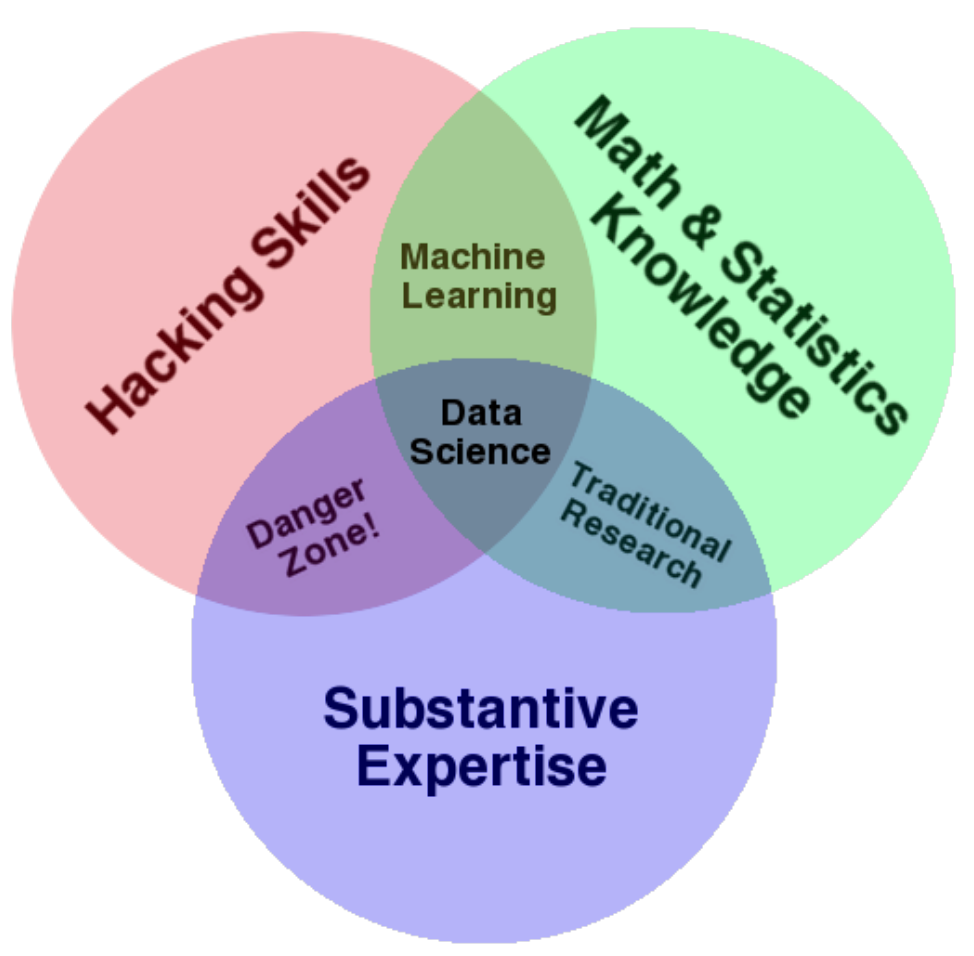

## Data Science ?

*A data scientist is someone who can obtain, scrub, explore, model and interpret data, blending hacking, statistics and machine learning. Data scientists not only are adept at working with data, but appreciate data itself as a first-class product.*

**– Hilary Mason, chief scientist at bit.ly**

## Data Science?

*Talking about data also evokes the **datascientist**, this five-legged sheep of data with **statistical, computer skills**, perfectly understanding **the business stakes** of the company… Is he also a fantasy of the ambient discourse on big data ?*

## Data Science?

*While there may exist profiles that come close to this description, reality shows most often that datascience, like science in general, does not happen alone but **in a group**.(…)*

*Another little-known fact about the datascientist is that he is first and foremost a **craftsman’s trade**. Each problem and each dataset always requires a specific approach that cannot be industrialized, which many people still don’t understand.*

## A fashion with ancient origins

[figure not shown]

[Johann Kepler](http://fr.wikipedia.org/wiki/Johannes_Kepler)

## A fashion with ancient origins

[figure not shown]

[Charles Joseph Minard](https://en.wikipedia.org/wiki/Charles_Joseph_Minard)

## A fashion with ancient origins

[Charles Joseph Minard](https://en.wikipedia.org/wiki/Charles_Joseph_Minard)

## A fashion with ancient origins

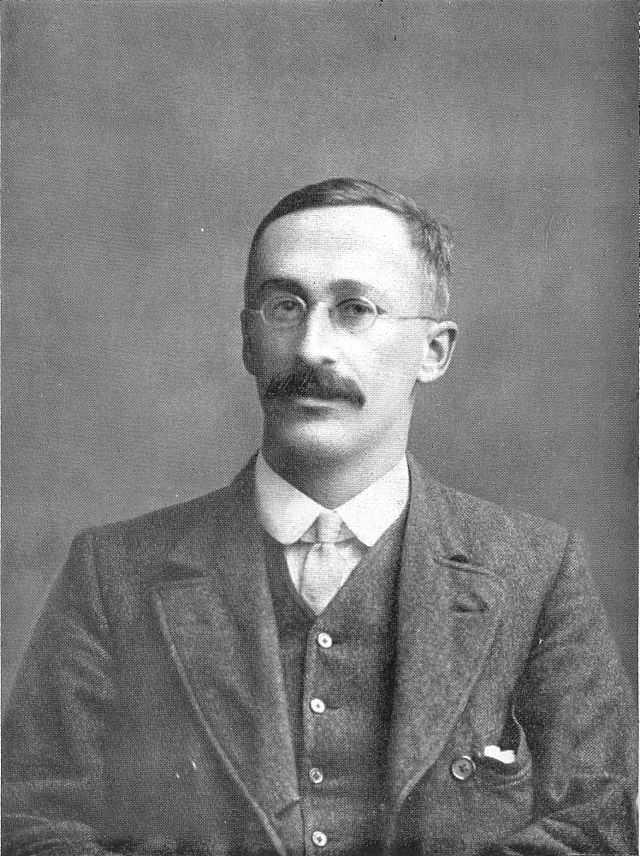

[William Sealy Gosset (Student)](https://en.wikipedia.org/wiki/William_Sealy_Gosset)

## Key competencies

### 1. Prepare data (DB)

Recover, mix, enrich, filter, clean, verify, format, transform data…

### 2. Models (ML/Stats)

Decision tree, regression, clustering, graphical model, SVM…

### 3. Interpret/share (Visualisation)

Graphics, Data visualization, Maps…

## Key competencies

### 1. Prepare data (DB) – 80% of the job

Recover, mix, enrich, filter, clean, verify, format, transform data…

### 2. Implementing a method a model (ML/Stats)

Decision tree, regression, clustering, graphical model, SVM…

### 3. Interpret/share (Visualisation) – 80% of the job

Graphics, Data visualization, Maps…

## Key competencies

### 1. Data Munging

Retrieve, mix, enrich, filter, clean, verify, format, transform data

### 2. Statistics

Traditional data analysis

### 3. Visualisation

Graphics, Data visualization, Maps…

## Course Outline

- handling R data with dplyr
- introduction to visualization, good practices & common mistakes
- ggplot and grammar of graphics
- spatial data
- introduction to cartography
- Dashboard (shiny)

## Assessment

- 1 written exam
- 1 open project
- LLM usage policy for the project

## AI tools – usage policy for the project

- **Authorized use**: help with code, documentation, ideation
- **Public discussions**: share the links to your LLM conversations ;  
  **their evaluation is part of the final grade**
- **Responsibility**: the student remains the author of the final deliverable
- **No AI**: choosing not to use AI is perfectly fine ;  
  **in case of doubt about the deliverable, oral defense via Zoom**

# Some projects

#### http://www.comeetie.fr/galerie/leboncoin/

# Some projects

#### https://www.comeetie.fr/galerie/francepixels2023/

# Some projects

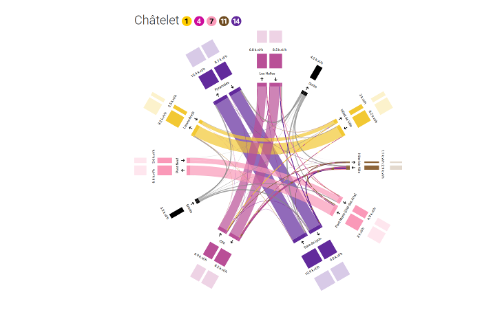

#### https://www.comeetie.fr/galerie/sankeystif/

# Smart-card data analysis

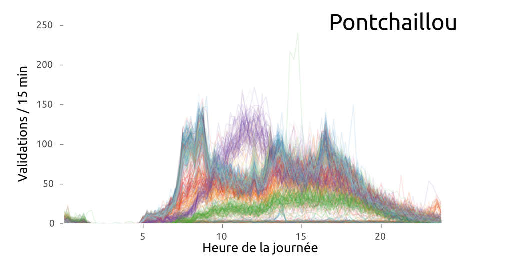

# Smart-card data analysis

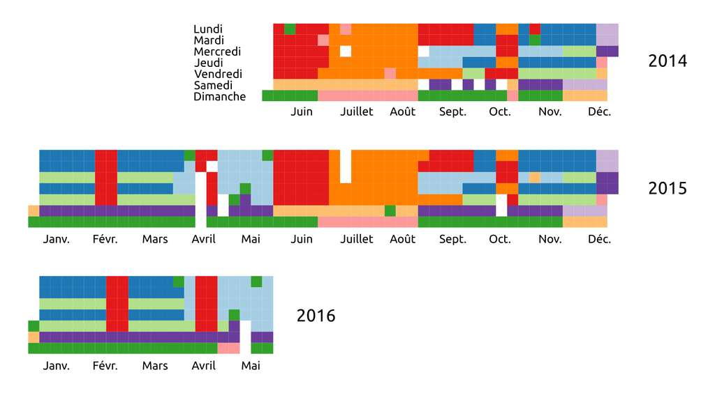

# Smart-card data analysis

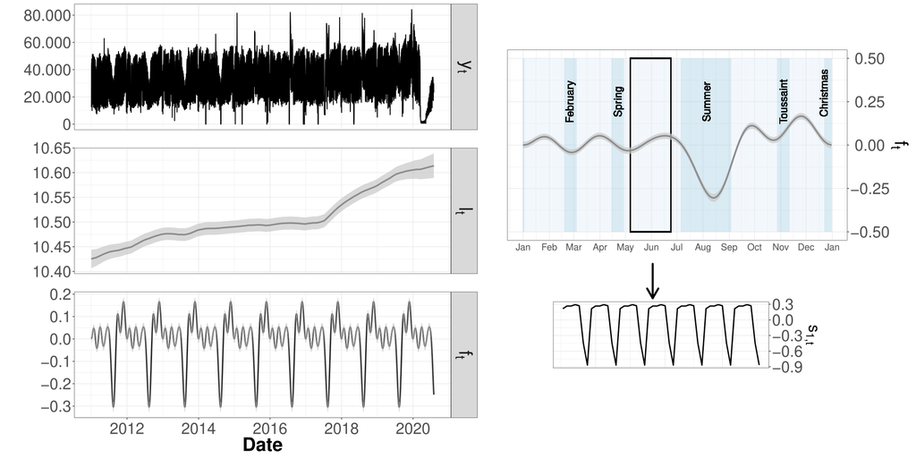

# Smart-card data analysis

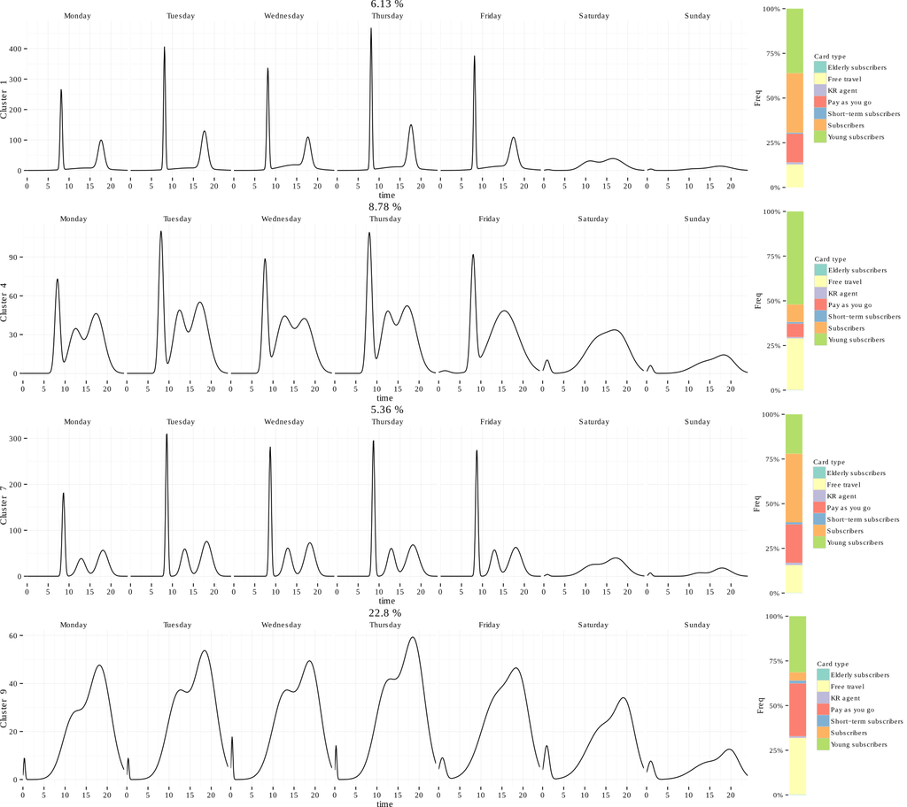

# Metro load prediction

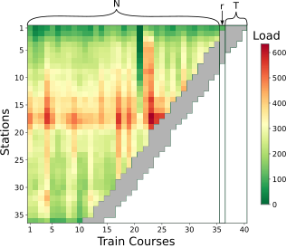

# Metro load prediction

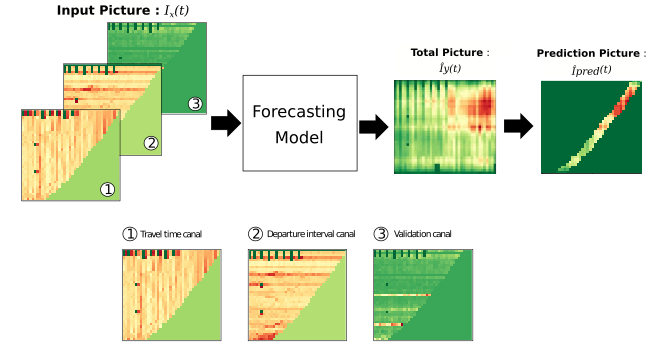

# Metro load prediction

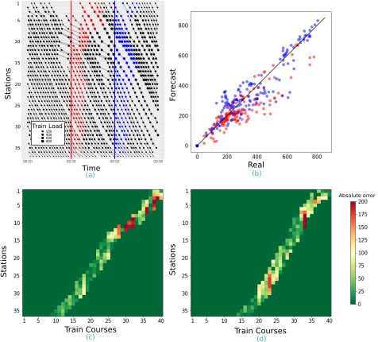